# Introduction to Tidyverse

Presented by William Pang

Last Revised: April 7, 2023

### Introduction and Some Basics

This tutorial assumes a basic understanding of R functions and some of its basic properties. However, to ensure everyone is brought up to speed, I will mix in a review of some basic concepts in this workshop. If you are struggling to follow this material, I highly suggest reviewing the [“First Steps with R”](https://marx.library.yale.edu/data-gis-statlab/statlab/workshops/statistical-support-workshop-materials) tutorial that can be found on the [StatLab](https://marx.library.yale.edu/data-gis-statlab/statlab) website.

To assign a variable in R, we use the leftward operator `<-`, which is unlike most other languages that utilizes `=`. Let’s try assigning a variable:

```r
a <- 3
b <- 15

a + b # Finding the sum of a and b
```

```
## [1] 18
```

Here we have created two objects in R — the variable `a` and `b`.

Another way to do this is to create a vector containing `a` and `b`, and use the `sum` function to add everything in the newly created vector.

```r
vectorSum <- c(a,b)

# Utilizing the sum function
sum(vectorSum)
```

```
## [1] 18
```

If you’re using R studio, you can find the objects stored in the environment tab on the right hand corner of your screen. Another way to check that the object is created is to type `a` (if you’re familiar with linux operating systems, you can also use the `ls()` function to list the “working directory” of variables).

### Installing and Loading Packages

You might have heard or already used packages such as `tidyverse`, `dplyr`, and other packages that pertain to the statistical analysis that you’re doing. As a quick refresher, packages — which are essentially a set of functions (think of it as buying kitchen appliances) — needs to first be installed on your local machine. To do so, you can utilize the `install.packages` function.

For this example, we would like to install the `tidyverse` and `shiny` in one line. Recall that we can use the combine argument, `c("packageOne", "packageTwo")`.

```r
packages <- c("tidyverse","shiny")
install.packages(packages)
```

If this is your first time installing the package onto your local machine, you should see a bunch of red text followed by the word *downloaded: size of file*.

```r
library(dplyr)
library(tidyverse)
```

### Reading in Data Files

If you’re here, I’m assuming that your favorite function is `read.csv`. However, `read.csv` might not be the best practice if you’re reading in data from other sources, especially data that contains dates which can become very messy in the long run. It’s good practice to know the classes of your data before tooling around with it — knowing your data types early can prevent a lot of potential headaches down the line.

To “force” variable classes in the different variables in your dataset, we use the `read_csv` command (as opposed to the read.csv command) that is part of the `tidyverse` package. Today, we’ll be working with a fun Pokemon dataset that is available on [Github](https://raw.githubusercontent.com/KeithGalli/pandas/master/pokemon_data.csv).

```r
pokemon <- read_csv('https://raw.githubusercontent.com/KeithGalli/pandas/master/pokemon_data.csv')
```

Great, if you now look at your console, you can see that we’re given information about the classes of the dataset. It’s always great to do a quick scan of this to see whether anything is weird. Just for fun, I tried using the `read.csv` function to read the pokemon dataset, and I noticed that `read.csv` reads in data with numbers as an interger type, whereas the `read_csv` reads numbers as a numeric/double type.

This is not awfully important for most of your use cases (other than the fact that integers uses less memory, which doesn’t really affect our usecase but might be a problem when you’re working with million and million of rows of data and data storage is expensive!). Anyway, sorry for that small tangent, but I’m assuming some of you might work with very large datasets in the future, so it’s always good to think about storage and that storage costs computational time and money!

Okay, now let’s pull out the full column specification. To do so, we call:

```r
spec(pokemon)
```

Notice that the `legendary` column is grouped under `lgl`, which means logical, or a boolean type (that is, a variable that will only give you TRUE or FALSE).

So why is it important that we know that this is a logical class type? For instance, we want out how many of the 800 Pokemons are legendary.

```r
sum(pokemon$Legendary)
```

```
## [1] 65
```

Say that the legendary variable was of the `chr` character class. Let’s hold this thought for now as I show you how to force the variable class for the data you’re reading.

```r
pokemon <- read_csv('https://raw.githubusercontent.com/KeithGalli/pandas/master/pokemon_data.csv',
  col_types = cols(
  `#` = col_double(),
  Name = col_character(),
  `Type 1` = col_character(),
  `Type 2` = col_character(),
  HP = col_double(),
  Attack = col_double(),
  Defense = col_double(),
  `Sp. Atk` = col_double(),
  `Sp. Def` = col_double(),
  Speed = col_double(),
  Generation = col_double(),
  Legendary = col_character() # Changed from col_logical()
  )
)
```

Now let’s try summing up the legendary variable to find out the number of legendary Pokemons in our Pokedex:

```r
sum(pokemon$Legendary)
```

We get an error statement that says: `Error in sum(pokemon$Legendary) : invalid 'type' (character) of argument`. This is what we expect, as it tells us that the strings cannot be summed!

As a reminder (or tip): if you’re unfamiliar with the inputs of a function, it’s always useful to consult `?functionName`. In this case, it would be `?read_csv`.

### Subsetting Data

As some of you who have played with Pokemons might know, Pokemons are classified based on types (for instance, Pikachu is an electric pokemon). In addition, some Pokemons are super strong, and they are known as legendary Pokemons. So going back to the Pokemon dataset, let’s do some exploratory data analysis:

```r
table(pokemon$Legendary) # Create a frequency table for legendary Pokemons
```

```
##
## FALSE  TRUE
##   735    65
```

```r
table(pokemon$`Type 1`) # Create a frequency table to see Pokemon types
```

```
##
##      Bug     Dark   Dragon Electric    Fairy Fighting     Fire   Flying
##       69       31       32       44       17       27       52        4
##    Ghost    Grass   Ground      Ice   Normal   Poison  Psychic     Rock
##       32       70       32       24       98       28       57       44
##    Steel    Water
##       27      112
```

```r
prop.table(table(pokemon$Legendary))
```

```
##
##   FALSE    TRUE
## 0.91875 0.08125
```

Okay, so we were able to use built in R functions to get some basic summary statistics. But what happens if we want to get more than just the proportions of legendary Pokemon but also learn something more about their attributes as a group? To do so, we would need to subset the data to only look at data rows that are legendary Pokemons.

```r
onlyLegendary <- pokemon[pokemon$Legendary == "TRUE", ]
summary(onlyLegendary)
```

```
##        #             Name              Type 1             Type 2
##  Min.   :144.0   Length:65          Length:65          Length:65
##  1st Qu.:381.0   Class :character   Class :character   Class :character
##  Median :483.0   Mode  :character   Mode  :character   Mode  :character
##  Mean   :470.2
##  3rd Qu.:642.0
##  Max.   :721.0
##        HP             Attack         Defense          Sp. Atk
##  Min.   : 50.00   Min.   : 50.0   Min.   : 20.00   Min.   : 50.0
##  1st Qu.: 80.00   1st Qu.:100.0   1st Qu.: 90.00   1st Qu.:100.0
##  Median : 91.00   Median :110.0   Median :100.00   Median :120.0
##  Mean   : 92.74   Mean   :116.7   Mean   : 99.66   Mean   :122.2
##  3rd Qu.:105.00   3rd Qu.:131.0   3rd Qu.:115.00   3rd Qu.:150.0
##  Max.   :150.00   Max.   :190.0   Max.   :200.00   Max.   :194.0
##     Sp. Def          Speed         Generation    Legendary
##  Min.   : 20.0   Min.   : 50.0   Min.   :1.000   Mode:logical
##  1st Qu.: 90.0   1st Qu.: 90.0   1st Qu.:3.000   TRUE:65
##  Median :100.0   Median :100.0   Median :4.000
##  Mean   :105.9   Mean   :100.2   Mean   :3.769
##  3rd Qu.:120.0   3rd Qu.:110.0   3rd Qu.:5.000
##  Max.   :200.0   Max.   :180.0   Max.   :6.000
```

Woah, this is a lot of information, some of which is redundant and unclear! Say I want to know the number of legendary Pokemons in our Pokeset or the mean HP among legendary Pokemons, I would need to type in my R console:

```r
nrow(onlyLegendary)
```

```
## [1] 65
```

```r
mean(onlyLegendary$'HP')
```

```
## [1] 92.73846
```

But knowing the mean HP or the number of legendary Pokemons is not very useful if we don’t compare it with something (in this case, non-legendary Pokemons). As you can already see, if we were to make a comparison with non-legendary Pokemons, we would need to create a repeat the exact same operations (i.e., subset the data, store it in a variable called `nonLegendary`, etc. ) which becomes extremely cumbersome. We’ll come back to this problem a bit later, once we’ve familiarzed ourselves with the pipe operator.

### Modifying Data

Here we will be introducing the concept of piping, which you might have been exposed to and is part of the `dplyr` package (which is part of `tidyverse`, which you’ve already installed!). The main idea of piping is really to simplify your code – you could theoretically do without piping, as you can see as we try and replicate some examples from above – but the advantages of piping should be obvious.

**Key Idea:** The pipe function takes the output of one function and passes it into another function as an argument

Let’s try doing the previous operation again, that is, to find the summary statistics of only legendary Pokemons.

```r
pokemon %>% filter(Legendary == "TRUE") %>% summary()
```

```
##        #             Name              Type 1             Type 2
##  Min.   :144.0   Length:65          Length:65          Length:65
##  1st Qu.:381.0   Class :character   Class :character   Class :character
##  Median :483.0   Mode  :character   Mode  :character   Mode  :character
##  Mean   :470.2
##  3rd Qu.:642.0
##  Max.   :721.0
##        HP             Attack         Defense          Sp. Atk
##  Min.   : 50.00   Min.   : 50.0   Min.   : 20.00   Min.   : 50.0
##  1st Qu.: 80.00   1st Qu.:100.0   1st Qu.: 90.00   1st Qu.:100.0
##  Median : 91.00   Median :110.0   Median :100.00   Median :120.0
##  Mean   : 92.74   Mean   :116.7   Mean   : 99.66   Mean   :122.2
##  3rd Qu.:105.00   3rd Qu.:131.0   3rd Qu.:115.00   3rd Qu.:150.0
##  Max.   :150.00   Max.   :190.0   Max.   :200.00   Max.   :194.0
##     Sp. Def          Speed         Generation    Legendary
##  Min.   : 20.0   Min.   : 50.0   Min.   :1.000   Mode:logical
##  1st Qu.: 90.0   1st Qu.: 90.0   1st Qu.:3.000   TRUE:65
##  Median :100.0   Median :100.0   Median :4.000
##  Mean   :105.9   Mean   :100.2   Mean   :3.769
##  3rd Qu.:120.0   3rd Qu.:110.0   3rd Qu.:5.000
##  Max.   :200.0   Max.   :180.0   Max.   :6.000
```

Here, I used the filter function in `tidyverse`, which is equivalent to the `subset` function in base R . We can immediately see that this makes the code way more concise and easy to follow (I don’t have to create a new variable called `onlyLegendary`, or use the dollar $ symbol a million times) .

I’m also going to use the opportunity to rename some of the variables in my dataset. For instance, the Pokedex number is represented with the pound `#` sign, which can be problematic as R might read it as a comment. I’m also going to rename some other variables while I’m at it for convenience in coding later.

To do so, we can use the `rename` function, where `new_variable_name = old_variable_name`.

```r
pokemon %>% rename(id = `#`, legendary = Legendary, type1 = `Type 1`, type2 = `Type 2`)
```

Okay, let’s check if the variables have been renamed.

```r
ls(pokemon)
```

```
##  [1] "#"          "Attack"     "Defense"    "Generation" "HP"
##  [6] "Legendary"  "Name"       "Sp. Atk"    "Sp. Def"    "Speed"
## [11] "Type 1"     "Type 2"
```

Wait, what just happened? The changes don’t seem to be saved when I call the `pokemon` data frame. This is because the pipe operation outputs the data in something called a `tibble`, but does not make changes to the original dataset. This can be incredibly useful in some contexts (for instance, you want to demonstrate that you don’t need to touch the original dataset for your analysis, which can be important for reproducibility), but for my purposes — which is to make the coding life a bit easier — I would like to permanently change my dataset.

```r
pokemon <- pokemon %>% rename(id = `#`, legendary = Legendary, type1 = `Type 1`, type2 = `Type 2`)
```

```r
ls(pokemon)
```

```
##  [1] "Attack"     "Defense"    "Generation" "HP"         "id"
##  [6] "legendary"  "Name"       "Sp. Atk"    "Sp. Def"    "Speed"
## [11] "type1"      "type2"
```

Say we want to see if there’s anything interesting if we add up the total points of each Pokemon’s attributes. Just to remind ourselves what we’re doing, let’s pull up the dataset again and look at the first two rows.

```r
head(pokemon, n = 2)
```

```
## # A tibble: 2 × 12
##      id Name      type1 type2     HP Attack Defense `Sp. Atk` `Sp. Def` Speed
##   <dbl> <chr>     <chr> <chr>  <dbl>  <dbl>   <dbl>     <dbl>     <dbl> <dbl>
## 1     1 Bulbasaur Grass Poison    45     49      49        65        65    45
## 2     2 Ivysaur   Grass Poison    60     62      63        80        80    60
## # … with 2 more variables: Generation <dbl>, legendary <lgl>
```

One question we might ask ourselves is whether Legendary Pokemons have a higher sum of points as compared to non-Legendary Pokemons. To add a new column that tabulates the total scores we need to use the mutate function and sum up the values from rows 5 to 10.

```r
pokemon <- pokemon %>% mutate(total = rowSums(.[5:10]))

# Always good practice to check if the function is doing what we want
print.data.frame(head(pokemon, n = 1))
```

```
##   id      Name type1  type2 HP Attack Defense Sp. Atk Sp. Def Speed Generation
## 1  1 Bulbasaur Grass Poison 45     49      49      65      65    45          1
##   legendary total
## 1     FALSE   318
```

Notice the dot `.` in the mutate function. The `.` function is equivalent to saying `rowsums(pokemon[5:10])`. But isn’t this the whole point of using the pipe operator — to avoid this hassle?

Recall what the pipe function does. It takes the output of the LHS (left hand side) of the function and passes it to the RHS (right hand side).

However, some functions work better at “understanding” dataframes, while others work better at interpreting one dimensional vectors. The sum function is used to add up everything in a one dimension vector – as we saw in our very first example when I asked you to create a vector adding up `a+b`. But recall that from the pipe function, we’re feeding in a dataframe, not a specific column.

The take-home message here is to understand the general idea behind what a function is doing — and leave the nuts and bolts idiosyncrasies to Google or Stackoverflow.

Anyways, back to the task at hand: We’ve created a new column that tallies up the total points of each Pokemon’s attributes. Now the question of interest is comparing the total score of legendary Pokemons with non-Legendary Pokemons. Unfortunately, there is no clean solution using the filter function:

```r
onlyLegendary_avg <- pokemon %>% filter(legendary == "TRUE") %>% {sum(.$total)}/65
notLegendary_avg <- pokemon %>% filter(legendary == "FALSE") %>% {sum(.$total)}/(800-65)
# Print results
onlyLegendary_avg
```

```
## [1] 637.3846
```

```r
notLegendary_avg
```

```
## [1] 417.2136
```

Full transparency: I had to Google how to do this as well; in fact, I would never remember how to write this code on my own. In practice, we would never code like this — instead, we would rely on the `group_by` function.

### Collapsing Data

Okay, let’s dive into the `group_by` function. Let me first illustrate with an example and walk you through what we’ve done:

```r
pokemon %>%
  group_by(legendary) %>%
  summarize(count= n(), HP = mean(HP), Attack = mean(Attack), Defense = mean(Defense))
```

```
## # A tibble: 2 × 5
##   legendary count    HP Attack Defense
##   <lgl>     <int> <dbl>  <dbl>   <dbl>
## 1 FALSE       735  67.2   75.7    71.6
## 2 TRUE         65  92.7  117.     99.7
```

As the name suggests, the `group_by` function takes a table, segments it, and then performs operations based on the specified groups.

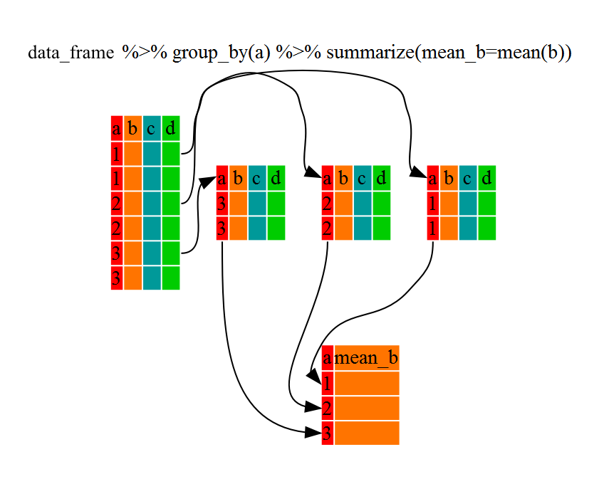

Let’s walk through what just happened in the above function. First, the `group_by` function “split” the dataset into two sets, if you will — a [735 x 12] set and a [65 x 12] dataframe. Then, we ran a `n()` function, which counts the rows in each of the “split” dataset. The `mean()` operation was then performed on the split dataset to calculate the mean HP for legendary and nonlegendary Pokémons, as well as the mean Attack points.

Cool! This is a really important function, because it has saved us a lot of time and hassle!

```r
stats <- pokemon %>%
  group_by(type1, legendary) %>%
  summarize(count= n(), HP = mean(HP), Attack = mean(Attack), Defense = mean(Defense))

stats
```

```
## # A tibble: 33 × 6
## # Groups:   type1 [18]
##    type1    legendary count    HP Attack Defense
##    <chr>    <lgl>     <int> <dbl>  <dbl>   <dbl>
##  1 Bug      FALSE        69  56.9   71.0    70.7
##  2 Dark     FALSE        29  64.7   86.9    68.7
##  3 Dark     TRUE          2  98    110.     92.5
##  4 Dragon   FALSE        20  72.6  103.     78.2
##  5 Dragon   TRUE         12 101.   127.    100.
##  6 Electric FALSE        40  57.3   66.1    65.4
##  7 Electric TRUE          4  84.5   98.8    75
##  8 Fairy    FALSE        16  70.9   57.2    63.9
##  9 Fairy    TRUE          1 126    131      95
## 10 Fighting FALSE        27  69.9   96.8    65.9
## # … with 23 more rows
```

```r
# To just output Psychic Pokemons
stats[stats$type1 == "Psychic", ]
```

```
## # A tibble: 2 × 6
## # Groups:   type1 [1]
##   type1   legendary count    HP Attack Defense
##   <chr>   <lgl>     <int> <dbl>  <dbl>   <dbl>
## 1 Psychic FALSE        43  67.7   55.0    61
## 2 Psychic TRUE         14  79.6  122.     88.2
```

### Joining Tables

Very commonly in research, you get datasets in different csv files or tables, and you’re asked to do combine the two tables for your analysis.

For the sake of demonstration, we will split the dataset into two.

```r
pokemon_left <- pokemon[, 1:6]
pokemon_right <- pokemon[, 7:12]

head(pokemon_left, n = 2)
```

```
## # A tibble: 2 × 6
##      id Name      type1 type2     HP Attack
##   <dbl> <chr>     <chr> <chr>  <dbl>  <dbl>
## 1     1 Bulbasaur Grass Poison    45     49
## 2     2 Ivysaur   Grass Poison    60     62
```

```r
head(pokemon_right, n = 2)
```

```
## # A tibble: 2 × 6
##   Defense `Sp. Atk` `Sp. Def` Speed Generation legendary
##     <dbl>     <dbl>     <dbl> <dbl>      <dbl> <lgl>
## 1      49        65        65    45          1 FALSE
## 2      63        80        80    60          1 FALSE
```

When we join two tables together, we must first ask: What is the commonality between the first table and the second table? What is the commonality that links both tables together?

Usually, there would be some kind of id (say employees id or Pokemon id) that we can reference on. Since this is a toy example and we simply halved the dataset, we would need to manually create our own indexing. Let us use the handy `mutate` function again:

```r
pokemon_left <- pokemon_left %>% mutate(index_left = 1:nrow(pokemon_left))
pokemon_right <- pokemon_right %>% mutate(index_right = 1:nrow(pokemon_right))

head(pokemon_left, n = 1)
```

```
## # A tibble: 1 × 7
##      id Name      type1 type2     HP Attack index_left
##   <dbl> <chr>     <chr> <chr>  <dbl>  <dbl>      <int>
## 1     1 Bulbasaur Grass Poison    45     49          1
```

```r
head(pokemon_right, n = 1)
```

```
## # A tibble: 1 × 7
##   Defense `Sp. Atk` `Sp. Def` Speed Generation legendary index_right
##     <dbl>     <dbl>     <dbl> <dbl>      <dbl> <lgl>           <int>
## 1      49        65        65    45          1 FALSE               1
```

```r
pokemon_merge <- merge(pokemon_left, pokemon_right, by.x = "index_left", by.y = "index_right")
head(pokemon_merge, n = 2)
```

```
##   index_left id      Name type1  type2 HP Attack Defense Sp. Atk Sp. Def Speed
## 1          1  1 Bulbasaur Grass Poison 45     49      49      65      65    45
## 2          2  2   Ivysaur Grass Poison 60     62      63      80      80    60
##   Generation legendary
## 1          1     FALSE
## 2          1     FALSE
```

Since we merged based on the left table, we get this extra `index_left` column that we don’t need. To remove this column, we can use the `select` function in tidyverse.

```r
pokemon_merge %>% select(-index_left)
```

### Wide to long conversion

Depending on the datset, you might want it to be either wide or long. Most datasets that you download/use will be in wide format, as it is easier to interpret and visualize. However, most of the processes running behind R using long, and if you’re writing custom functions to help with visualizations, it might be required to feed the dataset as a long format.

The way I like to remember the difference between wide and long is that the long format repeats variable names in the first column, whereas a wide format does not.

[figure not shown]

Let’s go back to our Pokemon example and subset it by `HP, Attack, Defense` to make it more manageable.

```r
pokemon_wide <- pokemon[, c("Name", "HP", "Attack", "Defense")]
head(pokemon_wide, n = 6);
```

```
## # A tibble: 6 × 4
##   Name                     HP Attack Defense
##   <chr>                 <dbl>  <dbl>   <dbl>
## 1 Bulbasaur                45     49      49
## 2 Ivysaur                  60     62      63
## 3 Venusaur                 80     82      83
## 4 VenusaurMega Venusaur    80    100     123
## 5 Charmander               39     52      43
## 6 Charmeleon               58     64      58
```

Then, convert the table from wide to long using the `gather` function. Note that the `gather` function takes in three arguments: (1) The key (2) the value (3) the variables we want to group by (which will be displayed in key).

```r
pokemon_long <- pokemon_wide %>% gather(ability, value, HP:Defense);
head(pokemon_long, n = 6);
```

```
## # A tibble: 6 × 3
##   Name                  ability value
##   <chr>                 <chr>   <dbl>
## 1 Bulbasaur             HP         45
## 2 Ivysaur               HP         60
## 3 Venusaur              HP         80
## 4 VenusaurMega Venusaur HP         80
## 5 Charmander            HP         39
## 6 Charmeleon            HP         58
```

To transform a dataset from long to wide, we can use the `spread` function.

```r
pokemon_wide1 <- pokemon_long %>% spread(ability, value)
head(pokemon_wide1, n= 6)
```

```
## # A tibble: 6 × 4
##   Name                    Attack Defense    HP
##   <chr>                    <dbl>   <dbl> <dbl>
## 1 Abomasnow                   92      75    90
## 2 AbomasnowMega Abomasnow    132     105    90
## 3 Abra                        20      15    25
## 4 Absol                      130      60    65
## 5 AbsolMega Absol            150      60    65
## 6 Accelgor                    70      40    80
```

### A soft introduction into ggplot

Finally, we will do a soft introduction into ggplot. This is an extensive topic and requires a workshop on its own (which I also teach and notes can be found [here](https://williampangbest1.github.io/yalestatlab/ggplot2.html)), but I want to quickly highlight how ggplot and tidyverse connects together.

Here’s an example code that we can use to create a histogram of Pokemons type:

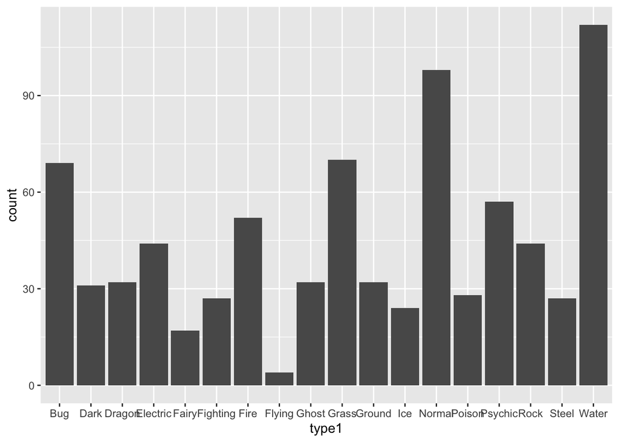

```r
ggplot(data = pokemon, aes(x = type1)) +
  geom_bar()
```

A few terminologies here, which again, requires a workshop in itself but for now we’ll just have to memorize it. ggplot is analogous to building a multilayered cake: first, you need to specifiy the dataset you’re using (`data= pokemon`). Then, we would need to define what goes into the x and y axis — this goes under `aes` , which means aesthetics mapping. Finally, we need to define what the graph looks like — do you want a bar plot, a line plot, or a dotplot? Since we’re creating a histogram, we can only get a bar plot, which can be defined with `geom_bar()`.

If you think about it, this is essentially a pipe operator! Note that when we define what goes into the x-axis, we didn’t have to specify `pokemon$type1`, because what we’re essentially doing is `pokemon %>% type1`.

We can also flip the question in another way: How do we get the counts of Pokemon by type and output it as a table? We should already be able to do this by now.

```r
pokemon %>% group_by(type1) %>% count()
```

```
## # A tibble: 18 × 2
## # Groups:   type1 [18]
##    type1        n
##    <chr>    <int>
##  1 Bug         69
##  2 Dark        31
##  3 Dragon      32
##  4 Electric    44
##  5 Fairy       17
##  6 Fighting    27
##  7 Fire        52
##  8 Flying       4
##  9 Ghost       32
## 10 Grass       70
## 11 Ground      32
## 12 Ice         24
## 13 Normal      98
## 14 Poison      28
## 15 Psychic     57
## 16 Rock        44
## 17 Steel       27
## 18 Water      112
```

Let’s say you were given the choice to pick one Pokemon by its type, with the goal being to pick the strongest Pokemon. Which one would you pick? We can plot it out and see.

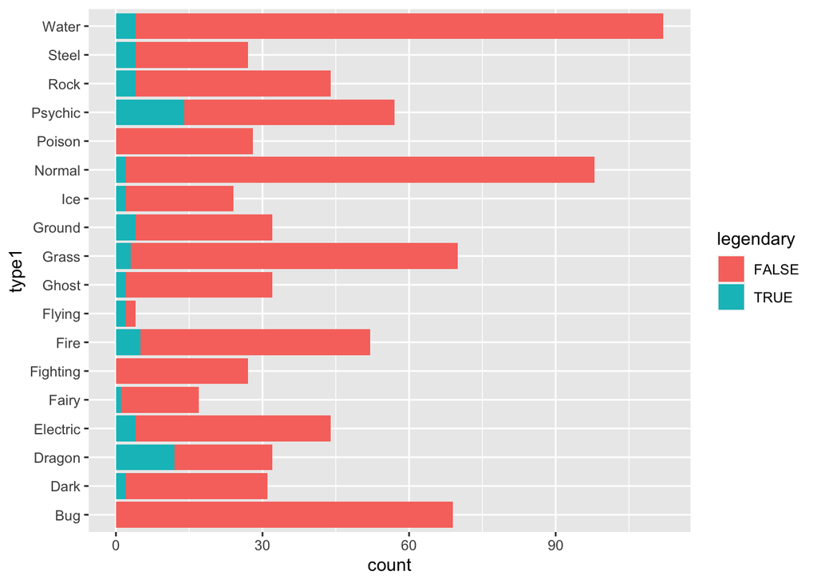

```r
ggplot(data = pokemon, aes(x = type1, fill = legendary)) +
  geom_bar() +
  coord_flip()
```

I would either pick a dragon type or psychic type Pokemon. Again, we could also write this with the `group_by` function:

```r
pokemon %>% group_by(type1, legendary) %>% count()
```

[output not shown]